# Sparrow GATK Quality thresholds

15/11/2017

# GATK annotations

The final step of GATK allows you to apply hard filters to the dataset - however the default filters may not be sufficient for your dataset - so you need to check them.

Here we have 40,635 biallelic SNPs randomly drawn from chr15 to approximate the genome-wide distribution.

## Allele count

This is simply the number of alleles in genotypes for the ALT allele

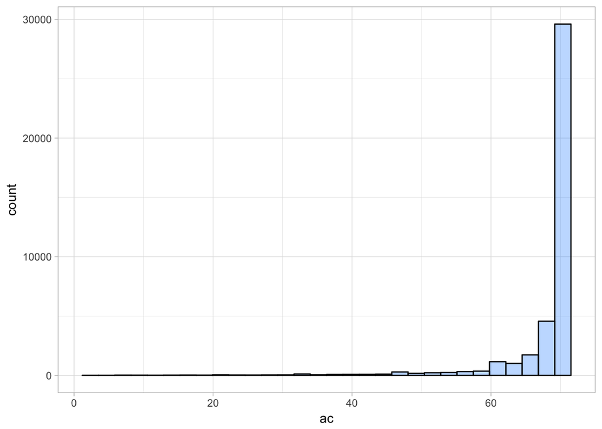

## Allele frequency for the ALT allele

This is the frequency of the alternative allele.

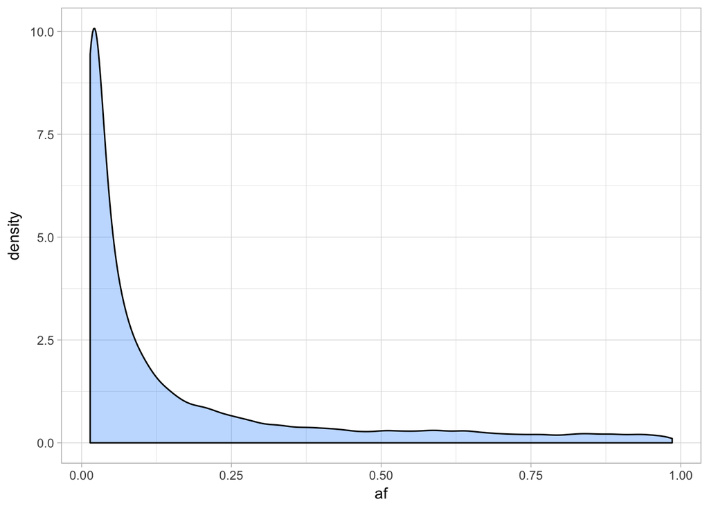

## QualbyDepth - QD

QD is variant confidence (QUAL) divided by unfiltered depth of **non-hom ref** samples - i.e. it is quality normalised by depth. Default recommendation is to remove all variants < 2 - this is indicated on the figure below.

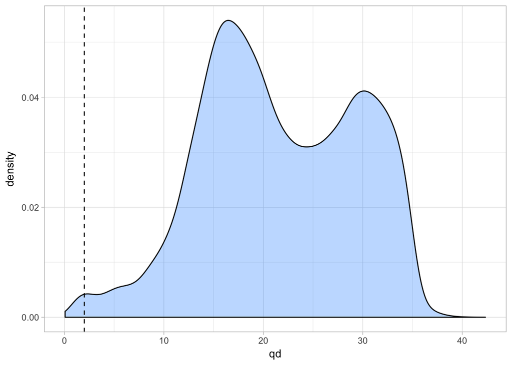

Our distribution is bimodal. We might expect two peaks because of a difference in homozygous versus heterozygous non-ref hets. **GATK suggests a QD filter of >2 but 5 would be applicable here**

## Fisher Strand Bias

This is the Phred-scaled probability of strand bias - i.e. a non-ref allele is associated with either the forward or reverse read than the reference. The higher this value, the more likely there is bias.

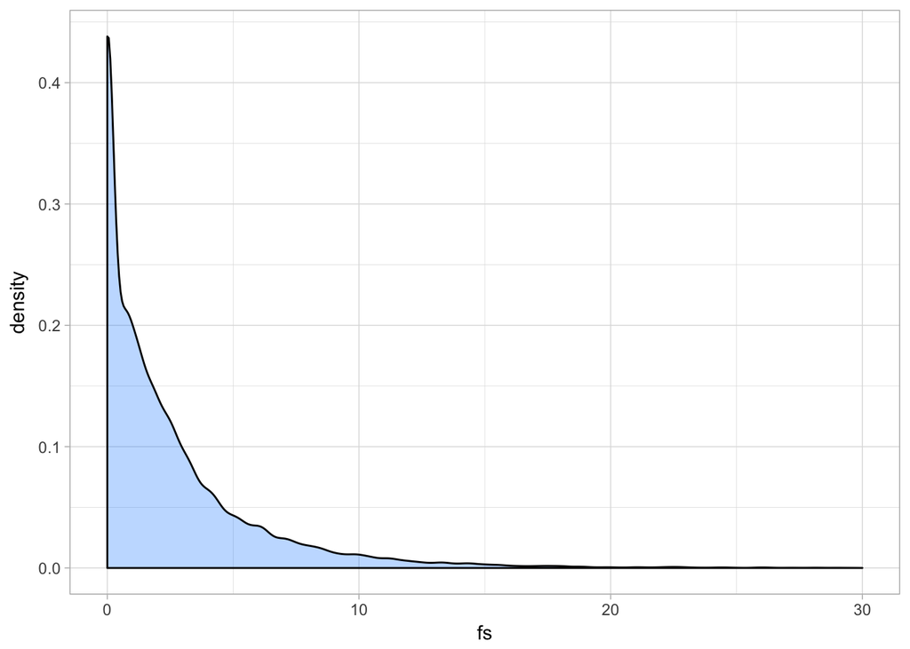

Few alleles seem to have bias, so we can set this to about **10**

## Mapping quality

RSM of MQ at all reads at a site. Rather than a mean, this incorporates the distribution. Good MQ will be around 60. The default is marked here, at 40.

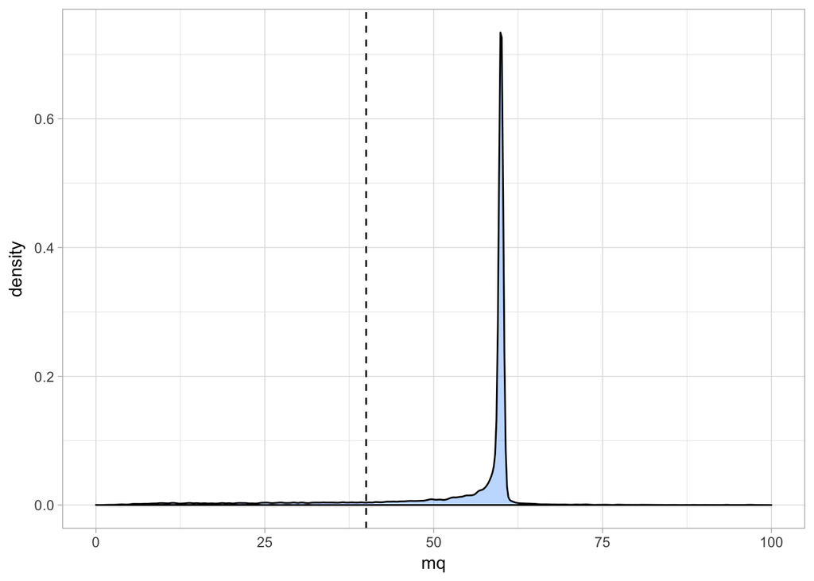

Although we could raise this to 50, it seems fine to **keep the default**.

## ReadPosRankSum - Ranks sum of read position

This is similar to the last test - but instead of mapping qualities, it tests the difference in read position between alternate and reference alleles. Negative values suggest the alternate allele is found at the end of a read more than the reference, and positive is the opposite. The default is -8.

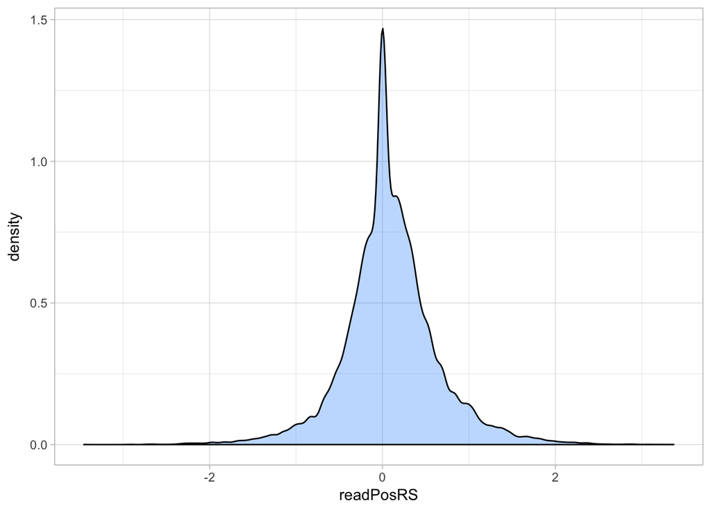